# Word Prediction - Milestone Report

Brian Costa

March 20, 2016

## Summary

This SwiftKey capstone project involves word, or n-gram, prediction using a model based on a corpus of 3 documents. The corpus includes english blogs, twitter output, and news articles provided by SwiftKey.

Since the overall objective seems to be to predict the next word, regardless of medium, I combined the three types of documents into one corpus. The documents are large so I started with a 1% random sample from each. The following perl code was used to extract the sample. (from http://stackoverflow.com/questions/22261082/load-a-small-random-sample-from-a-large-csv-file-into-r-data-frame)

```
perl -ne 'print if (rand() < .01)' biglist.txt > subset.txt
```

This is what the original files and the samples look like in terms of size and number of lines

```
$ ls -l
total 569424
-rw-r--r-- 1 Brian 197609 210160014 Mar  9 18:50 en_US.blogs.txt
-rw-r--r-- 1 Brian 197609 205811889 Mar  9 18:50 en_US.news.txt
-rw-r--r-- 1 Brian 197609 167105338 Mar  9 18:50 en_US.twitter.txt
$

$ wc -l *.txt
   899288 en_US.blogs.txt
  1010242 en_US.news.txt
  2360148 en_US.twitter.txt
$


$ wc -l *.txt
   8992 en_US.blogs.sample.txt
  10145 en_US.news.sample.txt
  23408 en_US.twitter.sample.txt
  42545 total
$
```

## Corpus Creation

The sample files are combined into one corpus, the corpus is manipulated to make it more usable. I decided to leave the stop words in since this is concerning predicting the next word and the stopword list are the most probably next words…

```r
library(ggplot2)
library(tm)
#library(RWeka)
library(wordcloud)
# create a corpus
corp  <-Corpus(DirSource("final/en_US/samples"), readerControl = list(language="lat"))
#summary(corp)
corp <- tm_map(corp, content_transformer(removeNumbers))
corp <- tm_map(corp, content_transformer(removePunctuation))
corp <- tm_map(corp, content_transformer(stripWhitespace))
corp <- tm_map(corp, content_transformer(tolower))
#corp <- tm_map(corp, removeWords, stopwords("english"))
corp <- tm_map(corp, stemDocument, language = "english")
```

## DTM Creation for Individual Words

From the corpus a DTM is created in order to gather some statistics about the frequency of occurrence of individual words in the corpus.

A DTM is a transposed TDM, DTM seemed more suitable for this

```r
# create a DTM

dtm <-DocumentTermMatrix(corp)
dtm <- removeSparseTerms(dtm, 0.75)

#inspect(dtm)

# find terms with a frequency higher than 100
#findFreqTerms(dtm, lowfreq=100)

# take colsums (occurrences across docuemnts), sort decreasing and see what we have
dtm2<-as.matrix(dtm)
frequency<-colSums(dtm2)
frequency <- sort(frequency, decreasing=TRUE)
head(frequency)
```

```
##   the   and  that   for   you  with
## 48318 24269 11289 11075  9408  7138
```

## Wordcloud and Plots of Word Occurrences

A wordcloud of the top 100 words and a plot of the words having more than 3000 occurrences accross the three documents

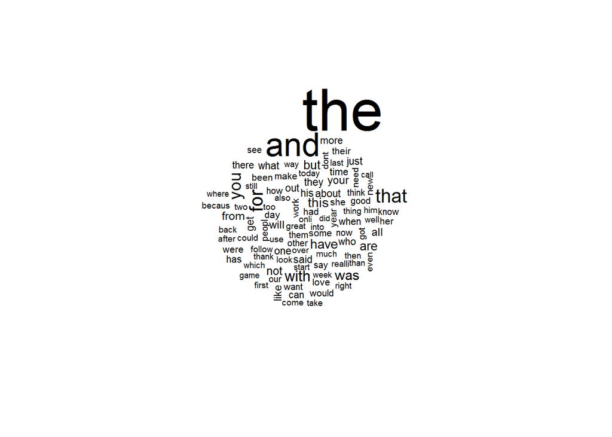

```r
words <- names(frequency)
wordcloud(words[1:100], frequency[1:100])
```

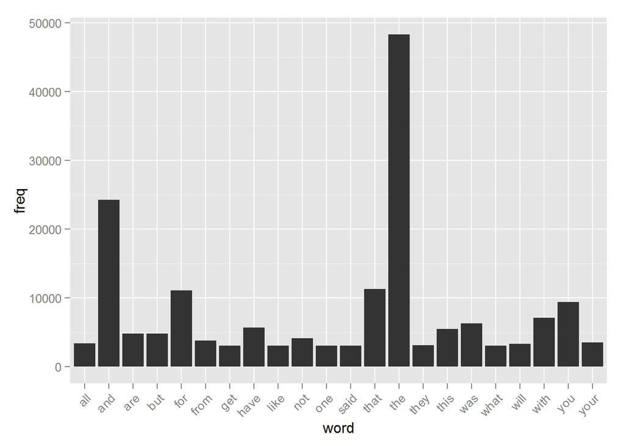

```r
wf <- data.frame(word=names(frequency), freq=frequency)
p <- ggplot(subset(wf, freq>3000), aes(word, freq))
p <- p + geom_bar(stat="identity")
p <- p + theme(axis.text.x=element_text(angle=45, hjust=1))
p
```

## Bigrams and Trigrams

After experimenting with bi and tri-grams in this corpus for a while (with and without the inclusion of the stopwords) I suceeded in breaking Java on this machine causing the loading of RWeka to crash R before I was able to publish it. Below is the commented out code. I need another day or so to figure out what happened. The coading approach was the same as for single words - sorted counts, word clouds, and plots.

```r
#BigramTokenizer <- function(x) NGramTokenizer(x, Weka_control(min = 2, max = 2))
#bi_tdm <- TermDocumentMatrix(corp, control = list(tokenize = BigramTokenizer))
#bi_tdm <- removeSparseTerms(bi_tdm, 0.75)
#inspect(bi_tdm[1:3,1:3])

#findFreqTerms(bi_tdm, lowfreq=100) # find n-grams with a frequency higher than 100

#bi_tdm2<-as.matrix(bi_tdm)
#frequency<-rowSums(bi_tdm2)
#frequency <- sort(frequency, decreasing=TRUE)
#head(frequency)

#words <- names(frequency)
#wordcloud(words[1:10], frequency[1:10])

#p <- ggplot(subset(wf, freq>3000), aes(word, freq))
#p <- p + geom_bar(stat="identity")
#p <- p + theme(axis.text.x=element_text(angle=45, hjust=1))
#p




#TrigramTokenizer <- function(x) NGramTokenizer(x, Weka_control(min = 3, max = 3))
#tri_tdm <- TermDocumentMatrix(corp, control = list(tokenize = TrigramTokenizer))
#tri_tdm <- removeSparseTerms(tri_tdm, 0.75)
#inspect(tdm[1:3,1:3])

#findFreqTerms(tri_tdm, lowfreq=100) # find n-grams with a frequency higher than 100

#tri_tdm2<-as.matrix(tri_tdm)
#frequency<-rowSums(tri_tdm2)
#frequency <- sort(frequency, decreasing=TRUE)
#head(frequency)

#words <- names(frequency)
#wordcloud(words[1:10], frequency[1:10])

#p <- ggplot(subset(wf, freq>3000), aes(word, freq))
#p <- p + geom_bar(stat="identity")
#p <- p + theme(axis.text.x=element_text(angle=45, hjust=1))
#p
```

## Final Prediction Approach

Since this is only 1% of the data and takes a while to process I may try tau which has better multi-core support. Once the n-grams are constructed then building either Markov chains, or simply dataframes, to allow the selection of the highest probability “third word” given a matching first and second word. I need to understand Markov chains better - since we are not actually concerned with generating a distributon of suggestions I’m not sure they are necessary for this assignment. I also need to understand using the J48 models and how they fit in with this project. Lots to learn.